# Lab 5

Shanpeng Li

### Stratified Tests While Adjusting for Covariates

Another test of interest is to compare the hazard rates of two (or more) populations while adjusting for some other covariate(s). In such cases, a regression framework would be more appealing since these models generally account for multiple confounding covariates. This will be discussed later.

However, for adjusting with one covariate, we can simply use existing output. Let’s look at Example 7.7 on pg. 220.

**Note:** There are typos in the book and dataset in `R`. The 23rd subject should have entries (2, 1, 176, 1, 80, 38) and $Z$ should be 0.36 with a $p$-value of $.718$!

Suppose we were intrested in testing the null hypothesis of no difference in the leukemia-free survival rate between graft type (allogenic, autologous) while adjusting for the patient’s disease state (Non-Hodgkins, Hodgkins).

```r
library(survival)
library(KMsurv)
data(hodg)

head(hodg)
```

```
##   gtype dtype time delta score wtime
## 1     1     1   28     1    90    24
## 2     1     1   32     1    30     7
## 3     1     1   49     1    40     8
## 4     1     1   84     1    60    10
## 5     1     1  357     1    70    42
## 6     1     1  933     0    90     9
```

```r
hodg[23, ] <- c(2, 1, 176, 1, 80, 38)

#Looking only at NHL
survdiff(Surv(time, delta) ~ gtype, data = hodg, subset = (dtype == 1))
```

```
## Call:
## survdiff(formula = Surv(time, delta) ~ gtype, data = hodg, subset = (dtype ==
##     1))
##
##          N Observed Expected (O-E)^2/E (O-E)^2/V
## gtype=1 11        5     7.31     0.728      1.58
## gtype=2 12        9     6.69     0.794      1.58
##
##  Chisq= 1.6  on 1 degrees of freedom, p= 0.2
```

```r
#Looking at Hodgkin's Patients
survdiff(Surv(time, delta) ~ gtype, data = hodg, subset = (dtype == 2))
```

```
## Call:
## survdiff(formula = Surv(time, delta) ~ gtype, data = hodg, subset = (dtype ==
##     2))
##
##          N Observed Expected (O-E)^2/E (O-E)^2/V
## gtype=1  5        5     1.89     5.095      6.36
## gtype=2 15        7    10.11     0.955      6.36
##
##  Chisq= 6.4  on 1 degrees of freedom, p= 0.01
```

```r
#Looking at treatment while controlling for disease type
survdiff(Surv(time, delta) ~ gtype + strata(dtype), data = hodg)
```

```
## Call:
## survdiff(formula = Surv(time, delta) ~ gtype + strata(dtype),
##     data = hodg)
##
##          N Observed Expected (O-E)^2/E (O-E)^2/V
## gtype=1 16       10      9.2    0.0697     0.132
## gtype=2 27       16     16.8    0.0381     0.132
##
##  Chisq= 0.1  on 1 degrees of freedom, p= 0.7
```

However, the results become insignificant when we stratify on disease.

## Median Comparison for Two-Sample Right-Censored Survival Data using the Control Median Test

As mentioned earlier, one can test whether two samples have the same median survival time using a $Z$-test. Here, we will look at an alternative through bootstrapping. Below is code on how to use the `quantileControlTest` in the `controlTest` package. We will look at Example 7.9.

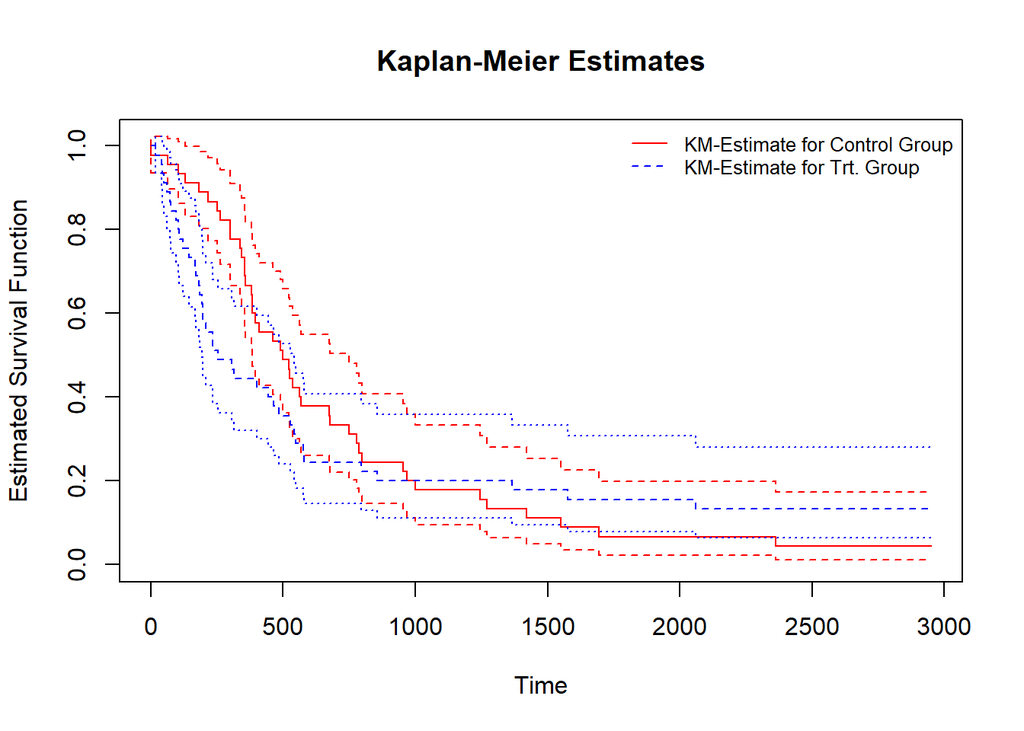

```
## $quantile
## [1] 0.5
##
## $sample1
## [1] 499
##
## $sample2
## [1] 254
##
## $Z
## [1] -1.652438
##
## $se
## [1] 0.0874129
##
## $pval
## [1] 0.098
##
## $B
## [1] 1000
```

```r
library(controlTest)
t1 <- c(1, 63, 105, 129, 182, 216, 250, 262, 301, 301,
       342, 354, 356, 358, 380, 383, 383, 338, 394, 408,
       460, 489, 499, 523, 524, 535, 562, 569, 675, 676,
       748, 778, 786, 797, 955, 968, 1000, 1245, 1271, 1420,
       1551, 1694, 2363, 2754, 2950)
t2 <- c(17, 42, 44, 48, 60, 72, 74, 95, 103, 108, 122, 144,
       167, 170, 183, 185, 193, 195, 197, 208, 234, 235, 254,
       307, 315, 401, 445, 464, 484, 528, 542, 547, 577, 580,
       795, 855, 1366, 1577, 2060, 2412, 2486, 2796, 2802, 2934, 2988)
c1 <- c(rep(1, 43), 0, 0)
c2 <- c(rep(1, 39), rep(0, 6))
quantileControlTest(t1, c1, t2, c2, B = 1000, plots = TRUE) #R = number of bootstrap samples
```

## Cox’s Proportional Hazards Model (Section 8.1 - 8.2)

One of the most common models used in survival analysis is Cox’s proportional hazards model. Assuming that the covariates are time-invariant, a concept we will go over later in class, the Cox model aims to model the conditional hazard function through
$$h(t|\mathbf{x}) = h_{0}(t) \exp(\mathbf{x}^T\boldsymbol{\beta}),$$
where $h_{0}(t)$ is an unspecified baseline hazard function, $\boldsymbol{\beta} = (\beta_1, \ldots, \beta_p)$ is an unknown vector of regression coefficients, and $\mathbf{x}$ is a $p$-dimensional covariate vector. Cox’s partial likelihood method estimates $\boldsymbol{\beta}$ through maximizing the log-partial likelihood. Alternate log-partial likelihoods exist in the presence of ties. Numerical optimization is used to find the maximum partial likelihood estimates (MPLE).

It is very straightforward to implement in both `R` and `SAS`. In `R`, we would use the `coxph` function and the syntax is similar to that of `lm`.

Let us look at Example 8.1 from K&M. We will use the `btrial` dataset from the textbook.

```r
#Example 8.1 (pg. 247)
data(btrial)
head(btrial)
```

```
##   time death im
## 1   19     1  1
## 2   25     1  1
## 3   30     1  1
## 4   34     1  1
## 5   37     1  1
## 6   46     1  1
```

```r
fit <- coxph(Surv(time, death) ~ im, data = btrial)
summary(fit)
```

```
## Call:
## coxph(formula = Surv(time, death) ~ im, data = btrial)
##
##   n= 45, number of events= 24
##
##      coef exp(coef) se(coef)     z Pr(>|z|)
## im 0.9802    2.6650   0.4349 2.254   0.0242 *
## ---
## Signif. codes:  0 '***' 0.001 '**' 0.01 '*' 0.05 '.' 0.1 ' ' 1
##
##    exp(coef) exp(-coef) lower .95 upper .95
## im     2.665     0.3752     1.136      6.25
##
## Concordance= 0.583  (se = 0.042 )
## Likelihood ratio test= 4.45  on 1 df,   p=0.03
## Wald test            = 5.08  on 1 df,   p=0.02
## Score (logrank) test = 5.49  on 1 df,   p=0.02
```

### Interpretation

How would we interpret the coefficient estimates from a Cox model? Let’s take a look at the example above. Our covariate vector, $\mathbf{x}$, is coded as 1 = negative immunohistochemical response and 2 = positive immunohistochemical response. Let us look at the following ratio,
$$\frac{h(t|\mathbf{x} = 2)}{h(t|\mathbf{x} = 1)} = \frac{h_0(t)\exp(\hat{\beta}_1 * 2)}{h_0(t)\exp(\hat{\beta}_1 * 1)} = \exp(2\hat{\beta}_1 - \hat{\beta}_1) = \exp(\hat{\beta}_1).$$
Therefore, $\exp(\hat{\beta}_1)$ is defined as the ratio of two conditional hazards. In otherwords, *the conditional hazard of a subject with a positive immunohistochemical response is $\exp(0.98) \approx 2.67$ that of the conditional hazard of a subject with a negative immunohistochemical response.*

Note that the interpretation is in terms of hazards, which are defined as
$$h(t) = \lim_{\Delta t \to 0} \frac{\Pr(t \leq T \leq t + \Delta t | T \geq t)}{\Delta t}.$$
Try explaining this to a layman. Thus, most reserchers replace the word hazard with the word *risk*. Now $\exp(\hat{\beta})$ can be seen as a measure of relative risk, which may be easier to understand/explain. However, it is important to know that although there is a change in terminology, the underlying quantity is not a probability (as risk is usually defined).

Note: For this example immunohistochemical response was coded as $\{1, 2\}$. The HR and interpretation will not change if we convert this to $\{0, 1\}$.

### Extracting Values

Let us see what we can extract for our `fit` variable.

```r
logLik(fit)
```

```
## 'log Lik.' -81.52065 (df=1)
```

```r
coef(fit)
```

```
##        im
## 0.9801995
```

```r
vcov(fit)
```

```
##           im
## im 0.1891289
```

Important information we can extract include the log-partial likelihood (`logLik`), variance-covariance matrix (`vcov`), and coefficient estimates (`coef`).